# gghistostats

Indrajeet Patil

2018-09-30

The function `ggstatsplot::gghistostats` can be used for **data exploration** and to provide an easy way to make **publication-ready histograms** with appropriate and selected statistical details embedded in the plot itself. In this vignette we will explore several examples of how to use it.

Some instances where you would want to use `gghistostats`-

- to inspect distribution of a continuous variable
- to test if the mean of a sample variable is different from a specified value (population parameter)

## Distribution of a sample with `gghistostats`

Let’s begin with a very simple example from the `psych` package (`psych::sat.act`), a sample of 700 self-reported scores on the SAT Verbal, SAT Quantitative and ACT tests. ACT composite scores may range from 1 - 36. National norms have a mean of 20.

```r
# loading needed libraries
library(ggstatsplot)
library(psych)
library(dplyr)

# looking at the structure of the data using glimpse
dplyr::glimpse(x = psych::sat.act)
```

```
#> Observations: 700
#> Variables: 6
#> $ gender    <int> 2, 2, 2, 1, 1, 1, 2, 1, 2, 2, 1, 2, 1, 2, 2, 2, 2, 2...
#> $ education <int> 3, 3, 3, 4, 2, 5, 5, 3, 4, 5, 3, 4, 4, 4, 3, 4, 3, 4...
#> $ age       <int> 19, 23, 20, 27, 33, 26, 30, 19, 23, 40, 23, 34, 32, ...
#> $ ACT       <int> 24, 35, 21, 26, 31, 28, 36, 22, 22, 35, 32, 29, 21, ...
#> $ SATV      <int> 500, 600, 480, 550, 600, 640, 610, 520, 400, 730, 76...
#> $ SATQ      <int> 500, 500, 470, 520, 550, 640, 500, 560, 600, 800, 71...
```

To get a simple histogram with no statistics and no special information. `gghistostats` will by default choose a binwidth `max(x) - min(x) / sqrt(N)`. You should always check this value and explore multiple widths to find the best to illustrate the stories in your data since histograms are sensitive to binwidth.

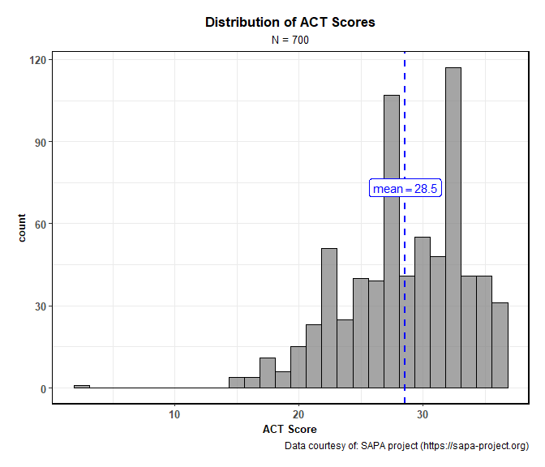

```r
ggstatsplot::gghistostats(
    data = psych::sat.act,                              # data from which variable is to be taken
    x = ACT,                                            # numeric variable
    results.subtitle = FALSE,                           # don't run statistical tests
    messages = FALSE,                                   # turn off messages
    xlab = "ACT Score",                                 # x-axis label
    title = "Distribution of ACT Scores",               # title for the plot
    subtitle = "N = 700",                               # subtitle for the plot
    caption = "Data courtesy of: SAPA project (https://sapa-project.org)", # caption for the plot
    centrality.k = 1                                    # show 1 decimal places for centrality label
  )
```

## Statistical analysis with `gghistostats`

The authors note that “the score means are higher than national norms suggesting both self selection for people taking on line personality and ability tests and a self reporting bias in scores.” Let’s display the national norms (labeled as “Test”) and test (using `results.subtitle = TRUE`) the hypothesis that our sample mean is the same as our national population mean of 20 using a parametric one sample t-test (`type = "p"`). To demonstrate some of the options available we’ll also:

1. Change the overall theme with `ggtheme = ggthemes::theme_tufte()`
2. Make the histogram bars a different color with `bar.fill = "#D55E00"`
3. Plot proportions on the y axes with `bar.measure = "proportion"`
4. Turn messages on to receive additional diagnostic information with `messages = TRUE`
5. Compute information about the Bayes Factor (`bf.message = TRUE`, see below)

```
#> Note: Shapiro-Wilk Normality Test for ACT : p-value = < 0.001
```

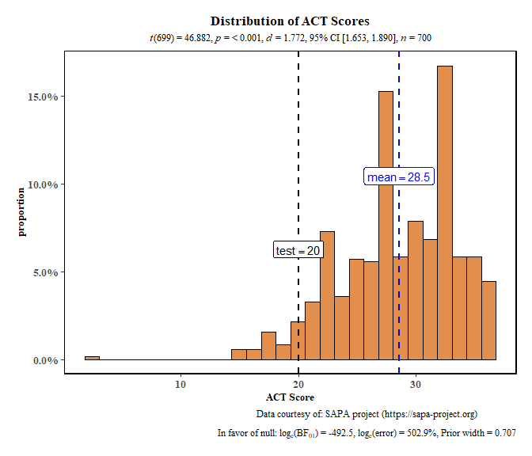

```r
ggstatsplot::gghistostats(
    data = psych::sat.act,                              # data from which variable is to be taken
    x = ACT,                                            # numeric variable
    results.subtitle = TRUE,                            # run statistical tests
    messages = TRUE,                                    # turn on messages
    bar.measure = "proportion",                         # proportions
    xlab = "ACT Score",                                 # x-axis label
    title = "Distribution of ACT Scores",               # title for the plot
    type = "p",                                         # one sample t-test
    bf.message = TRUE,                                  # display Bayes method results
    ggtheme = ggthemes::theme_tufte(),                  # changing default theme
    bar.fill = "#D55E00",                               # change fill color
    test.value = 20,                                    # test value
    test.value.line = TRUE,                             # show a vertical line at `test.value`
    caption = "Data courtesy of: SAPA project (https://sapa-project.org)", # caption for the plot
    centrality.k = 1                                    # show 1 decimal places for centrality label
  )
```

`gghistostats` computed Bayes Factors to quantify the likelihood of the **research** (BF10) and the **null** hypothesis (BF01). In our current example, the Bayes Factor value provides **very strong evidence** [(Kass and Rafferty, 1995)](https://www.stat.washington.edu/raftery/Research/PDF/kass1995.pdf) in favor of the research hypothesis: these ACT scores are much higher than the national average. The log(Bayes factor) of 492.5 means the odds are 7.54e+213:1 that this sample is different.

## Grouped analysis with `grouped_gghistostats`

What if we want to do the same analysis separately for each gender? In that case, we will have to either write a `for` loop or use `purrr`, none of which seem like an exciting prospect.

`ggstatsplot` provides a special helper function for such instances: `grouped_gghistostats`. This is merely a wrapper function around `ggstatsplot::combine_plots`. It applies `gghistostats` across all **levels** of a specified **grouping variable** and then combines the individual plots into a single plot. Note that the grouping variable can be anything: conditions in a given study, groups in a study sample, different studies, etc.

Let’s see how we can use this function to apply `gghistostats` to accomplish our task.

```
#> Note: 95% CI for robsut location measure median, Huber Psi computed with  500 bootstrap samples.
#> Note: 95% CI for robsut location measure median, Huber Psi computed with  500 bootstrap samples.
```

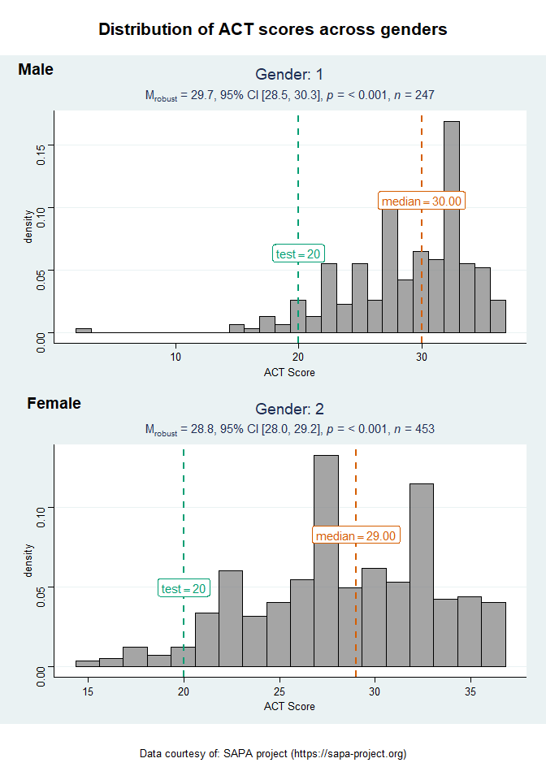

```r
ggstatsplot::grouped_gghistostats(
  # arguments relevant for ggstatsplot::gghistostats
  data = psych::sat.act,                        # same dataset
  x = ACT,                                      # same outcome variable
  xlab = "ACT Score",
  grouping.var = gender,                        # grouping variable males = 1, females = 2
  title.prefix = "Gender",                      # prefix for the fixed title
  k = 1,                                        # number of decimal places in results
  type = "r",                                   # robust test: one-sample percentile bootstrap
  robust.estimator = "mom",                     # changing the robust estimator used
  test.value = 20,                              # test value against which sample mean is to be compared
  test.value.line = TRUE,                       # show a vertical line at `test.value`
  bar.measure = "density",                      # density
  centrality.para = "median",                   # plotting centrality parameter
  centrality.color = "#D55E00",                 # color for centrality line and label
  test.value.color = "#009E73",                 # color for test line and label
  messages = FALSE,                             # turn off messages
  ggtheme = ggthemes::theme_stata(),            # changing default theme
  ggstatsplot.layer = FALSE,                    # turn off ggstatsplot theme layer
  # arguments relevant for ggstatsplot::combine_plots
  title.text = "Distribution of ACT scores across genders",
  caption.text = "Data courtesy of: SAPA project (https://sapa-project.org)",
  nrow = 2,
  ncol = 1,
  labels = c("Male","Female")
)
```

As can be seen from these plots, the mean value is much higher than the national norm. Additionally, we see the benefits of plotting this data separately for each gender. We can *see* the differences in distributions.

## Grouped analysis with `purrr`

Although this is a quick and dirty way to explore a large amount of data with minimal effort, it does come with an important limitation: reduced flexibility. For example, if we wanted to add, let’s say, a separate `test.value` argument for each gender, this is not possible with `grouped_gghistostats`. For cases like these, or to run separate kinds of tests (robust for some, parametric for other, while Bayesian for some other levels of the group) it would be better to use `purrr`. See the associated vignette here: https://indrajeetpatil.github.io/ggstatsplot/articles/purrr_examples.html

# Suggestions

If you find any bugs or have any suggestions/remarks, please file an issue on GitHub: https://github.com/IndrajeetPatil/ggstatsplot/issues

# Session Information

```r
options(width = 200)
```